# Introduction to the analysis

**On this oportunity the data that we will be exploring is the "No show appointment" data which collects information from 100k medical appointments in Brazil and is focused on the question of whether or not patients show up for their appointment.**

*These are the variables incluided with their definition:*

PatientID: ID of the patient that solicited the appointment  
AppointmentID: ID of the appointment  
Gender: The gender (M or F) of the patient  
ScheduledDay:The day that the patient set up their appointment.  
AppointmentDay:The day the patient actually went to the appointment.  
Age: Age of the patient  
Neighbourhood: indicates the location of the hospital.  
Scholarship: indicates whether or not the patient is enrolled in Brasilian welfare program "Bolsa Família".  
Hipertension: 1 if the patient has hipertension, 0 if not  
Diabetes: 1 if the patient has diabetes, 0 if not  
Alcoholism: 1 if the patient has alcoholism, 0 if not  
Handcap:Can be up to 4  
SMS_received: 1 if the SMS was received, 0 if not  
**No-show: It says ‘No’ if the patient showed up to their appointment, and ‘Yes’ if they did not show up.**

### In this data analysis we will be answering the following questions:

**1) What factors are important for us to know in order to predict if a patient will show up for their scheduled appointment?**  
**2) Is the welfare a good or bad incentive for people to go to their appointment?**  
**3) What are the illness that tend to miss more their appointment**  
**4) Does sending an SMS helps people to show up to their appointment?**

# Data Wrangling

### Gather:

A section where we import the libraries and packages used for the analysis and read the archive that includes the data.

```python
import pandas as pd
```

```python
import numpy as np
```

```python
import matplotlib.pyplot as plt
```

```python
%matplotlib inline
```

```python
import seaborn as sns
```

```python
df = pd.read_csv(r'C:\Users\bianc\Downloads\noshowappointment.csv')
```

### Assess:

A section where we assess the dataset and look for problems that may present difficulties for the future exploration

```python
df.head(10)
```

|  | PatientId | AppointmentID | Gender | ScheduledDay | AppointmentDay | Age | Neighbourhood | Scholarship | Hipertension | Diabetes | Alcoholism | Handcap | SMS_received | No-show |
| --- | --- | --- | --- | --- | --- | --- | --- | --- | --- | --- | --- | --- | --- | --- |
| 0 | 2.987250e+13 | 5642903 | F | 2016-04-29T18:38:08Z | 2016-04-29T00:00:00Z | 62 | JARDIM DA PENHA | 0 | 1 | 0 | 0 | 0 | 0 | No |
| 1 | 5.589978e+14 | 5642503 | M | 2016-04-29T16:08:27Z | 2016-04-29T00:00:00Z | 56 | JARDIM DA PENHA | 0 | 0 | 0 | 0 | 0 | 0 | No |
| 2 | 4.262962e+12 | 5642549 | F | 2016-04-29T16:19:04Z | 2016-04-29T00:00:00Z | 62 | MATA DA PRAIA | 0 | 0 | 0 | 0 | 0 | 0 | No |
| 3 | 8.679512e+11 | 5642828 | F | 2016-04-29T17:29:31Z | 2016-04-29T00:00:00Z | 8 | PONTAL DE CAMBURI | 0 | 0 | 0 | 0 | 0 | 0 | No |
| 4 | 8.841186e+12 | 5642494 | F | 2016-04-29T16:07:23Z | 2016-04-29T00:00:00Z | 56 | JARDIM DA PENHA | 0 | 1 | 1 | 0 | 0 | 0 | No |
| 5 | 9.598513e+13 | 5626772 | F | 2016-04-27T08:36:51Z | 2016-04-29T00:00:00Z | 76 | REPÚBLICA | 0 | 1 | 0 | 0 | 0 | 0 | No |
| 6 | 7.336882e+14 | 5630279 | F | 2016-04-27T15:05:12Z | 2016-04-29T00:00:00Z | 23 | GOIABEIRAS | 0 | 0 | 0 | 0 | 0 | 0 | Yes |
| 7 | 3.449833e+12 | 5630575 | F | 2016-04-27T15:39:58Z | 2016-04-29T00:00:00Z | 39 | GOIABEIRAS | 0 | 0 | 0 | 0 | 0 | 0 | Yes |
| 8 | 5.639473e+13 | 5638447 | F | 2016-04-29T08:02:16Z | 2016-04-29T00:00:00Z | 21 | ANDORINHAS | 0 | 0 | 0 | 0 | 0 | 0 | No |
| 9 | 7.812456e+13 | 5629123 | F | 2016-04-27T12:48:25Z | 2016-04-29T00:00:00Z | 19 | CONQUISTA | 0 | 0 | 0 | 0 | 0 | 0 | No |

```python
df.describe()
```

[output not shown]

```python
df.shape
```

```
(110527, 14)
```

```python
df.dtypes
```

```
PatientId         float64
AppointmentID       int64
Gender             object
ScheduledDay       object
AppointmentDay     object
Age                 int64
Neighbourhood      object
Scholarship         int64
Hipertension        int64
Diabetes            int64
Alcoholism          int64
Handcap             int64
SMS_received        int64
No-show            object
dtype: object
```

```python
df.info()
```

```
<class 'pandas.core.frame.DataFrame'>
RangeIndex: 110527 entries, 0 to 110526
Data columns (total 14 columns):
 #   Column          Non-Null Count   Dtype
---  ------          --------------   -----
 0   PatientId       110527 non-null  float64
 1   AppointmentID   110527 non-null  int64
 2   Gender          110527 non-null  object
 3   ScheduledDay    110527 non-null  object
 4   AppointmentDay  110527 non-null  object
 5   Age             110527 non-null  int64
 6   Neighbourhood   110527 non-null  object
 7   Scholarship     110527 non-null  int64
 8   Hipertension    110527 non-null  int64
 9   Diabetes        110527 non-null  int64
 10  Alcoholism      110527 non-null  int64
 11  Handcap         110527 non-null  int64
 12  SMS_received    110527 non-null  int64
 13  No-show         110527 non-null  object
dtypes: float64(1), int64(8), object(5)
memory usage: 11.8+ MB
```

```python
df.nunique()
```

```
PatientId          62299
AppointmentID     110527
Gender                 2
ScheduledDay      103549
AppointmentDay        27
Age                  104
Neighbourhood         81
Scholarship            2
Hipertension           2
Diabetes               2
Alcoholism             2
Handcap                5
SMS_received           2
No-show                2
dtype: int64
```

```python
df.duplicated().sum()
```

```
0
```

### Clean:

After assesing the dataset we could interpretate that none of the columns has null values nor duplicate values as the respective codes of "df.info()" and "df.duplicated().sum()" show us.  
-> However, one of the important focus for the next step of cleaning the data, is the type of data of *ScheduledDay* and *AppointmentDay* which are in the format of object (str) and can be difficult to work with.  
-> On the other hand, we will be making changes on the negative ages and create a new boolean column for "No-show" to get the correlation matrix and see the variables that have a bigger impact on showing up or not to the appointment.

**First, we change the columns that shows dates and time that are of the type "object" to a "datetime" type**

```python
df['ScheduledDay'] = pd.to_datetime(df['ScheduledDay'])
```

```python
df['AppointmentDay'] = pd.to_datetime(df['AppointmentDay'])
```

**Next, due to a negative minimun value of Age shown in the describe code, which is inconsistent, we decided to change it to "0" to have a cleaner dataset.**

```python
df.Age=df.Age.mask(df.Age.lt(0),0)
df.describe()
```

|  | PatientId | AppointmentID | Age | Scholarship | Hipertension | Diabetes | Alcoholism | Handcap | SMS_received |
| --- | --- | --- | --- | --- | --- | --- | --- | --- | --- |
| count | 1.105270e+05 | 1.105270e+05 | 110527.000000 | 110527.000000 | 110527.000000 | 110527.000000 | 110527.000000 | 110527.000000 | 110527.000000 |
| mean | 1.474963e+14 | 5.675305e+06 | 37.088883 | 0.098266 | 0.197246 | 0.071865 | 0.030400 | 0.022248 | 0.321026 |
| std | 2.560949e+14 | 7.129575e+04 | 23.110190 | 0.297675 | 0.397921 | 0.258265 | 0.171686 | 0.161543 | 0.466873 |
| min | 3.921784e+04 | 5.030230e+06 | 0.000000 | 0.000000 | 0.000000 | 0.000000 | 0.000000 | 0.000000 | 0.000000 |
| 25% | 4.172614e+12 | 5.640286e+06 | 18.000000 | 0.000000 | 0.000000 | 0.000000 | 0.000000 | 0.000000 | 0.000000 |
| 50% | 3.173184e+13 | 5.680573e+06 | 37.000000 | 0.000000 | 0.000000 | 0.000000 | 0.000000 | 0.000000 | 0.000000 |
| 75% | 9.439172e+13 | 5.725524e+06 | 55.000000 | 0.000000 | 0.000000 | 0.000000 | 0.000000 | 0.000000 | 1.000000 |
| max | 9.999816e+14 | 5.790484e+06 | 115.000000 | 1.000000 | 1.000000 | 1.000000 | 1.000000 | 4.000000 | 1.000000 |

**After cleaning the data, we will be exploring patterns that can be useful to respond some questions like..**  
*What factors are important for us to know in order to predict if a patient will show up for their scheduled appointment?*

```python
df.info()
```

```
<class 'pandas.core.frame.DataFrame'>
RangeIndex: 110527 entries, 0 to 110526
Data columns (total 14 columns):
 #   Column          Non-Null Count   Dtype
---  ------          --------------   -----
 0   PatientId       110527 non-null  float64
 1   AppointmentID   110527 non-null  int64
 2   Gender          110527 non-null  object
 3   ScheduledDay    110527 non-null  datetime64[ns, UTC]
 4   AppointmentDay  110527 non-null  datetime64[ns, UTC]
 5   Age             110527 non-null  int64
 6   Neighbourhood   110527 non-null  object
 7   Scholarship     110527 non-null  int64
 8   Hipertension    110527 non-null  int64
 9   Diabetes        110527 non-null  int64
 10  Alcoholism      110527 non-null  int64
 11  Handcap         110527 non-null  int64
 12  SMS_received    110527 non-null  int64
 13  No-show         110527 non-null  object
dtypes: datetime64[ns, UTC](2), float64(1), int64(8), object(3)
memory usage: 11.8+ MB
```

```python
df["No-show"].value_counts()
```

```
No     88208
Yes    22319
Name: No-show, dtype: int64
```

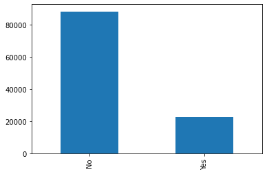

```python
df["No-show"].value_counts().plot(kind="bar")
```

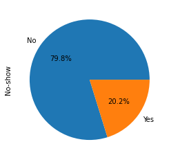

```python
df["No-show"].value_counts().plot(kind="pie", autopct ='%0.1f%%')
```

*With this graphic we see the proportion of the assistance. In which "Yes" as for people that did not went to their scheduled day appointment represent the 20% of the sample. Meanwhile, the resting 80% are people that went on their scheduled day.*

```
array([[<AxesSubplot:title={'center':'Age'}>]], dtype=object)
```

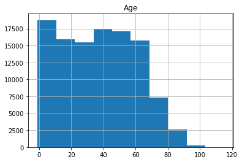

```python
df.hist("Age")
```

```python
count_noshow = df["No-show"].value_counts()
print(count_noshow)
```

```
No     88208
Yes    22319
Name: No-show, dtype: int64
```

*The following plot shows how more than half of the sample are females with a 65% vs 35% of man*

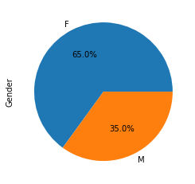

```python
df["Gender"].value_counts().plot(kind="pie", autopct ='%0.1f%%')
```

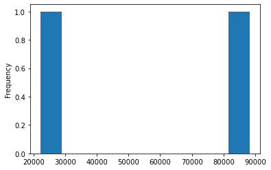

```python
df["No-show"].value_counts().plot(kind="hist")
```

**In order to get the correlation with the showing to an appointment or not, we added a new column of "No-show" where the "Yes" was replaced for "1" and "No" for "0"**

```python
df['Noshow_2'] = df['No-show'].replace(['Yes','No'],['1','0'])
```

```python
df.head()
```

|  | PatientId | AppointmentID | Gender | ScheduledDay | AppointmentDay | Age | Neighbourhood | Scholarship | Hipertension | Diabetes | Alcoholism | Handcap | SMS_received | No-show | Noshow_2 |
| --- | --- | --- | --- | --- | --- | --- | --- | --- | --- | --- | --- | --- | --- | --- | --- |
| 0 | 2.987250e+13 | 5642903 | F | 2016-04-29 18:38:08+00:00 | 2016-04-29 00:00:00+00:00 | 62 | JARDIM DA PENHA | 0 | 1 | 0 | 0 | 0 | 0 | No | 0 |
| 1 | 5.589978e+14 | 5642503 | M | 2016-04-29 16:08:27+00:00 | 2016-04-29 00:00:00+00:00 | 56 | JARDIM DA PENHA | 0 | 0 | 0 | 0 | 0 | 0 | No | 0 |
| 2 | 4.262962e+12 | 5642549 | F | 2016-04-29 16:19:04+00:00 | 2016-04-29 00:00:00+00:00 | 62 | MATA DA PRAIA | 0 | 0 | 0 | 0 | 0 | 0 | No | 0 |
| 3 | 8.679512e+11 | 5642828 | F | 2016-04-29 17:29:31+00:00 | 2016-04-29 00:00:00+00:00 | 8 | PONTAL DE CAMBURI | 0 | 0 | 0 | 0 | 0 | 0 | No | 0 |
| 4 | 8.841186e+12 | 5642494 | F | 2016-04-29 16:07:23+00:00 | 2016-04-29 00:00:00+00:00 | 56 | JARDIM DA PENHA | 0 | 1 | 1 | 0 | 0 | 0 | No | 0 |

```python
df["Noshow_2"].value_counts()
```

```
0    88208
1    22319
Name: Noshow_2, dtype: int64
```

```python
df['Noshow_2'] = df['Noshow_2'].astype(int)
```

```python
df.dtypes
```

```
PatientId                     float64
AppointmentID                   int64
Gender                         object
ScheduledDay      datetime64[ns, UTC]
AppointmentDay    datetime64[ns, UTC]
Age                             int64
Neighbourhood                  object
Scholarship                     int64
Hipertension                    int64
Diabetes                        int64
Alcoholism                      int64
Handcap                         int64
SMS_received                    int64
No-show                        object
Noshow_2                        int32
dtype: object
```

```python
corr = df.corr()
corr.style.background_gradient(cmap='coolwarm')
```

[output not shown]

# EDA

## Exploring, answering questions and visualization of the dataset:

### What factors are important for us to know in order to predict if a patient will show up for their scheduled appointment?

```python
df.head()
```

|  | PatientId | AppointmentID | Gender | ScheduledDay | AppointmentDay | Age | Neighbourhood | Scholarship | Hipertension | Diabetes | Alcoholism | Handcap | SMS_received | No-show | Noshow_2 |
| --- | --- | --- | --- | --- | --- | --- | --- | --- | --- | --- | --- | --- | --- | --- | --- |
| 0 | 2.987250e+13 | 5642903 | F | 2016-04-29 18:38:08+00:00 | 2016-04-29 00:00:00+00:00 | 62 | JARDIM DA PENHA | 0 | 1 | 0 | 0 | 0 | 0 | No | 0 |
| 1 | 5.589978e+14 | 5642503 | M | 2016-04-29 16:08:27+00:00 | 2016-04-29 00:00:00+00:00 | 56 | JARDIM DA PENHA | 0 | 0 | 0 | 0 | 0 | 0 | No | 0 |
| 2 | 4.262962e+12 | 5642549 | F | 2016-04-29 16:19:04+00:00 | 2016-04-29 00:00:00+00:00 | 62 | MATA DA PRAIA | 0 | 0 | 0 | 0 | 0 | 0 | No | 0 |
| 3 | 8.679512e+11 | 5642828 | F | 2016-04-29 17:29:31+00:00 | 2016-04-29 00:00:00+00:00 | 8 | PONTAL DE CAMBURI | 0 | 0 | 0 | 0 | 0 | 0 | No | 0 |
| 4 | 8.841186e+12 | 5642494 | F | 2016-04-29 16:07:23+00:00 | 2016-04-29 00:00:00+00:00 | 56 | JARDIM DA PENHA | 0 | 1 | 1 | 0 | 0 | 0 | No | 0 |

**In order to not repeat future calculates of proportions of the sample que create a function that does it:**

```python
def percentage_proportion(size):
    x = df['PatientId'].value_counts().sum()
    return (size/x) * 100
```

```python
percentage_proportion(10861)
```

```
9.826558216544374
```

### Now, we will group some variables with "No-show" to see how they behave

```python
df["Gender"].value_counts()
```

```
F    71840
M    38687
Name: Gender, dtype: int64
```

```python
df["No-show"].value_counts()
```

```
No     88208
Yes    22319
Name: No-show, dtype: int64
```

```python
counts = df.groupby(["Gender", "No-show"]).count()
counts
```

| Gender | No-show | PatientId | AppointmentID | ScheduledDay | AppointmentDay | Age | Neighbourhood | Scholarship | Hipertension | Diabetes | Alcoholism | Handcap | SMS_received | Noshow_2 |
| --- | --- | --- | --- | --- | --- | --- | --- | --- | --- | --- | --- | --- | --- | --- |
| F | No | 57246 | 57246 | 57246 | 57246 | 57246 | 57246 | 57246 | 57246 | 57246 | 57246 | 57246 | 57246 | 57246 |
|  | Yes | 14594 | 14594 | 14594 | 14594 | 14594 | 14594 | 14594 | 14594 | 14594 | 14594 | 14594 | 14594 | 14594 |
| M | No | 30962 | 30962 | 30962 | 30962 | 30962 | 30962 | 30962 | 30962 | 30962 | 30962 | 30962 | 30962 | 30962 |
|  | Yes | 7725 | 7725 | 7725 | 7725 | 7725 | 7725 | 7725 | 7725 | 7725 | 7725 | 7725 | 7725 | 7725 |

```python
counts_table = counts[["PatientId"]]
print(counts_table)
```

```
                PatientId
Gender No-show
F      No           57246
       Yes          14594
M      No           30962
       Yes           7725
```

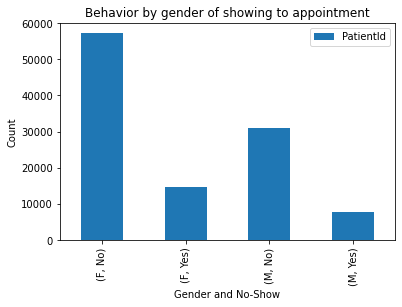

```python
counts_table.plot(kind = "bar", title = "Behavior by gender of showing to appointment")
plt.xlabel("Gender and No-Show")
plt.ylabel("Count")
```

```python
percentage_proportion(14794)
```

```
13.384964759741964
```

```python
percentage_proportion(7725)
```

```
6.989242447546753
```

```python
counts2 = df.groupby(["Scholarship", "No-show"]).count()
counts2
```

[output not shown]

```python
counts2_table = counts2[["PatientId"]]
print(counts2_table)
```

```
                     PatientId
Scholarship No-show
0           No           79925
            Yes          19741
1           No            8283
            Yes           2578
```

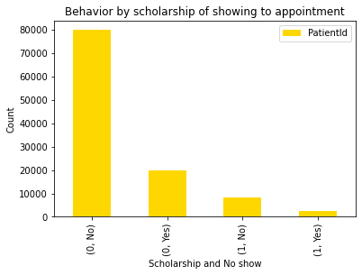

```python
counts2_table.plot(kind = "bar", title = "Behavior by scholarship of showing to appointment", color ="gold")
plt.xlabel("Scholarship and No show")
plt.ylabel("Count")
```

```python
percentage_proportion(79925)
```

```
72.31264758837207
```

```python
percentage_proportion(19741)
```

```
17.860794195083553
```

```python
percentage_proportion(2578)
```

```
2.3324617514272528
```

## Is the welfare a good or bad incentive for people to go to their appointment?

**As the results of the plot above demostrates**

The ones that went more to the appointment were the people that did not have the scholarship, being part of the 72.3% of the sample. On the other side, the group that miss the appointment the most also were the people that did not had scholarship with 17.86%.  
However, it is consequent that the people that had the welfare where the ones with the lower percentage of not assitant, represented by the 2.33% of the sample.

```python
counts2 = df.groupby(["Scholarship", "No-show"]).count()
counts2
```

| Scholarship | No-show | PatientId | AppointmentID | Gender | ScheduledDay | AppointmentDay | Age | Neighbourhood | Hipertension | Diabetes | Alcoholism | Handcap | SMS_received | Noshow_2 |
| --- | --- | --- | --- | --- | --- | --- | --- | --- | --- | --- | --- | --- | --- | --- |
| 0 | No | 79925 | 79925 | 79925 | 79925 | 79925 | 79925 | 79925 | 79925 | 79925 | 79925 | 79925 | 79925 | 79925 |
|  | Yes | 19741 | 19741 | 19741 | 19741 | 19741 | 19741 | 19741 | 19741 | 19741 | 19741 | 19741 | 19741 | 19741 |
| 1 | No | 8283 | 8283 | 8283 | 8283 | 8283 | 8283 | 8283 | 8283 | 8283 | 8283 | 8283 | 8283 | 8283 |
|  | Yes | 2578 | 2578 | 2578 | 2578 | 2578 | 2578 | 2578 | 2578 | 2578 | 2578 | 2578 | 2578 | 2578 |

```python
df["Neighbourhood"].value_counts()
```

```
JARDIM CAMBURI                 7717
MARIA ORTIZ                    5805
RESISTÊNCIA                    4431
JARDIM DA PENHA                3877
ITARARÉ                        3514
                               ...
ILHA DO BOI                      35
ILHA DO FRADE                    10
AEROPORTO                         8
ILHAS OCEÂNICAS DE TRINDADE       2
PARQUE INDUSTRIAL                 1
Name: Neighbourhood, Length: 81, dtype: int64
```

```python
df["Neighbourhood"].nunique()
```

```
81
```

```python
counts3 = df.groupby(["Hipertension", "No-show"]).count()
counts3
counts3_table = counts3[["PatientId"]]
print(counts3_table)
```

```
                      PatientId
Hipertension No-show
0            No           70179
             Yes          18547
1            No           18029
             Yes           3772
```

```python
counts4 = df.groupby(["Diabetes", "No-show"]).count()
counts4
counts4_table = counts4[["PatientId"]]
print(counts4_table)
```

```
                  PatientId
Diabetes No-show
0        No           81695
         Yes          20889
1        No            6513
         Yes           1430
```

```python
counts5 = df.groupby(["Alcoholism", "No-show"]).count()
counts5
counts5_table = counts4[["PatientId"]]
print(counts5_table)
```

```
                  PatientId
Diabetes No-show
0        No           81695
         Yes          20889
1        No            6513
         Yes           1430
```

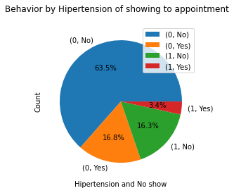

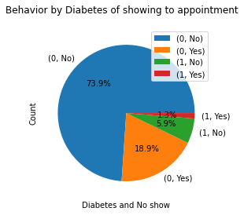

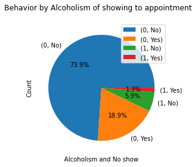

```python
counts3_table.plot(kind = "pie", title = "Behavior by Hipertension of showing to appointment", autopct ='%0.1f%%',  subplots =True)
plt.xlabel("Hipertension and No show")
plt.ylabel("Count")

counts4_table.plot(kind = "pie", title = "Behavior by Diabetes of showing to appointment", autopct ='%0.1f%%', subplots =True)
plt.xlabel("Diabetes and No show")
plt.ylabel("Count")

counts5_table.plot(kind = "pie", title = "Behavior by Alcoholism of showing to appointment", autopct ='%0.1f%%',  subplots =True)
plt.xlabel("Alcoholism and No show")
plt.ylabel("Count")
```

## What are the illness that tend to miss more their appointment?

```
                      PatientId
SMS_received No-show
0            No           62510
             Yes          12535
1            No           25698
             Yes           9784
```

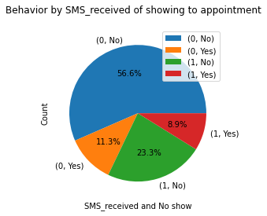

```python
counts6 = df.groupby(["SMS_received", "No-show"]).count()
counts6
counts6_table = counts6[["PatientId"]]
print(counts6_table)
counts6_table.plot(kind = "pie", title = "Behavior by SMS_received of showing to appointment", autopct ='%0.1f%%',  subplots =True)
plt.xlabel("SMS_received and No show")
plt.ylabel("Count")
```

## Does sending an SMS helps people to show up to their appointment?

The pie chart indicates that out of the 32.2% of the SMS_received, only 23.3% went to their appointment vs the 8.9% that did not.  
Meanwhile, a big portion of people that did not got SMS_received did went to the appointment as shown in the 56.6% of the sample.

*The following links were used as a reference for some codes:*  
https://stackoverflow.com/questions/29432629/plot-correlation-matrix-using-pandas  
https://www.datacamp.com/community/tutorials/python-select-columns?utm_source=adwords_ppc&utm_campaignid=1455363063&utm_adgroupid=65083631748&utm_device=c&utm_keyword=&utm_matchtype=b&utm_network=g&utm_adpostion=&utm_creative=332602034361&utm_targetid=aud-299261629574:dsa-429603003980&utm_loc_interest_ms=&utm_loc_physical_ms=1003325&gclid=Cj0KCQiAvP6ABhCjARIsAH37rbTQul1MXNiYQsXDH0i6X3JI72CHSOOQJ41YkZJgdqJO4a0wGonCIFYaAhqLEALw_wcB  
https://stackoverflow.com/questions/24183101/pandas-bar-plot-with-two-bars-and-two-y-axis

## Conclusion

On the first place, is important to talk about some of the limitations that this dataset has, which makes a barrier to make deeper conclusions like, for example, that there is missing a column that could include the neighbourhood where de patient lives and the km of distance it has to the location of the hospital. So it could show if the distance has a bigger impact in no showing to the appointment.

On the other hand, given that the sample is only of 100k it does not represent the behaviour of most people. Furthermore, because the average age of the data is 37, we could say that the dataset is quite young. Due to that, the illness present such as Diabetes, Hipertension are in a few amount of people from the sample. This limits, some further conclusions as to what illness may impact more in to show or not to the appointment and also, impacts the percentage of correlation with the "No-show" variable.

In spite of the lack of representation or other variables that could help to make a deeper analysis. The variables presented in the data were enough to answer some of the questions.

Firstly, because there is 65% of females in the dataset is consequent that they could be more females that did not show up to the appointment. This is true due to the "F, Yes" with 13.2% of the sample, which represents the females that did not showed to the appointment versus a 6,99% represented by man.

At the same time, this could also mean, that people that do not have scholarship find it more difficult to have an appointment which can implicate that they are more responsible so they go on their scheduled day.

On the other side, out of Hipertension, Diabetes and Alcoholism. Hipertension with a 3,4% is the illness that tends to miss more apointments, which could also be because is the one that has more presence between people from the dataset.